# Simple regression: Introduction

## Motivation

**Predicting the Price of a used car**

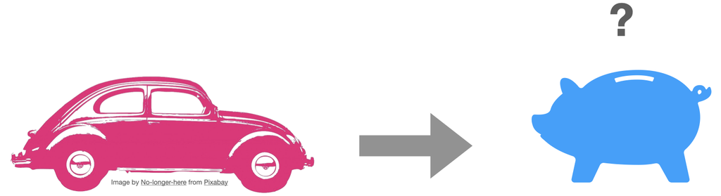

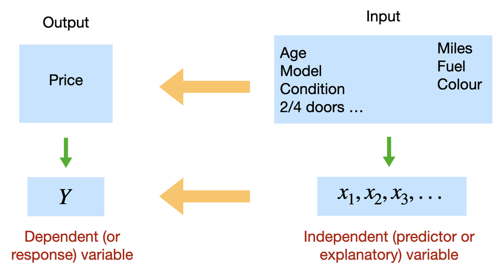

## Simple linear regression

**Simple linear regression (population)**
$$Y=\beta_0+\beta_1 x+\epsilon$$
In our example:
$$Price=\beta_0+\beta_1
Age+\epsilon$$

**Simple linear regression (sample)**
$$\hat{y}=b_0+b_1 x$$
where the coefficient $\beta_0$ (and its estimate $b_0$ or $\hat{\beta}_0$ ) refers to the $y$-intercept or simply the intercept or the constant of the regression line, and the coefficient $\beta_1$ (and its estimate $b_1$ or $\hat{\beta}_1$ ) refers to the slope of the regression line.

## Least-Squares criterion

- The **least-squares criterion** is that the line that best fits a set of data points is the one having the smallest possible sum of squared errors. The `errors’ are the vertical distances of the data points to the line.
- We need to use the data to estimate the values of the parameters $\beta_0$ and $\beta_1$, i.e. to fit a straight line to the set of points $\{(x_i , y_i )\}$. There are many straight lines we could use, so we need some idea of which is best. Clearly, a bad straight line model would be one that had many large errors, and conversely, a good straight line model will have, on average, small errors. We quantify this by the sum of squares of the errors:
  $$Q(\beta_0,\beta_1)=\sum_{i=1}^n
  \epsilon_i^2=\sum_{i=1}^n[y_i-(\beta_0 + \beta_1 x_i)]^2$$
  then the “line of best fit” will correspond to the line with values of $\beta_0$ and $\beta_1$ that minimises $Q(\beta_0,\beta_1)$.
- The regression line is the line that fits a set of data points according to the least squares criterion.
- The regression equation is the equation of the regression line.
- The regression equation for a set of $n$ data points is $\hat{y}=b_0+b_1\;x$, where
  $$b_1=\frac{S_{xy}}{S_{xx}}=\frac{\sum
  (x_i-\bar{x})(y_i-\bar{y})}{\sum (x_i-\bar{x})^2}
  \;\;\text{and}\;\; b_0=\bar{y}-b_1\; \bar{x}$$
- $y$ is the dependent variable (or response variable) and $x$ is the independent variable (predictor variable or explanatory variable).
- $b_0$ is called the **y-intercept** and $b_1$ is called the **slope**.

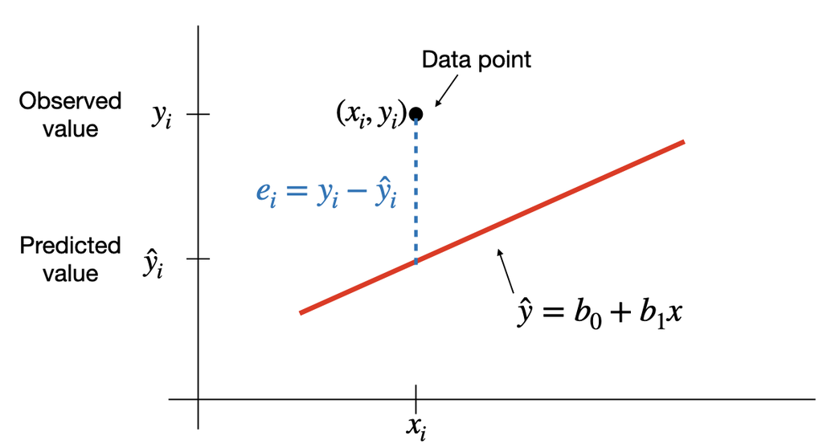

**SSE and the standard error**

This least square regression line minimizes the error sum of squares
$$SSE=\sum e^2_i =\sum
(y_i-\hat{y}_i)^2$$
The standard error of the estimate, $s_e=\sqrt{SSE/(n-2)}$, indicates how much, on average, the observed values of the response variable differ from the predicated values of the response variable.

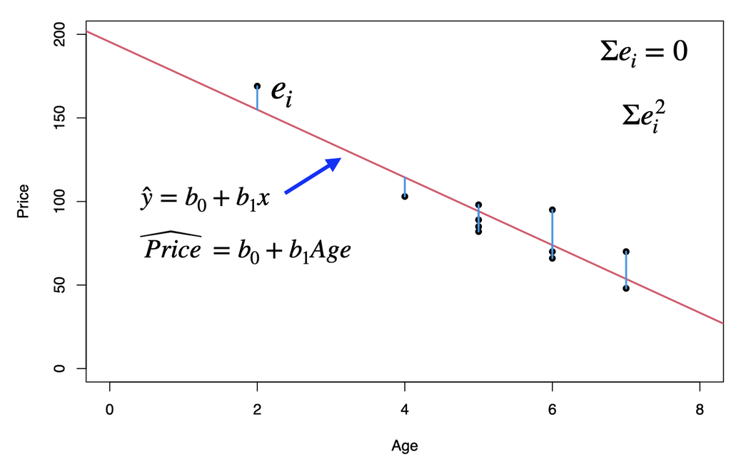

## Example: used cars (cont.)

The table below displays data on Age (in years) and Price (in hundreds of dollars) for a sample of cars of a particular make and model.(Weiss, 2012)

| Price ($y$) | Age ($x$) |
| --- | --- |
| 85 | 5 |
| 103 | 4 |
| 70 | 6 |
| 82 | 5 |
| 89 | 5 |
| 98 | 5 |
| 66 | 6 |
| 95 | 6 |
| 169 | 2 |
| 70 | 7 |
| 48 | 7 |

- For our example, *age* is the predictor variable and *price* is the response variable.
- The regression equation is $\hat{y}=195.47-20.26\;x$, where the slope $b_1=-20.26$ and the intercept $b_0=195.47$
- Prediction: for $x = 4$, that is we would like to predict the price of a 4-year-old car,
  $$\hat{y}=195.47-20.26 {\color{blue}(4)}= 114.43
  \;\;\text{or}\;\; \$ 11443$$

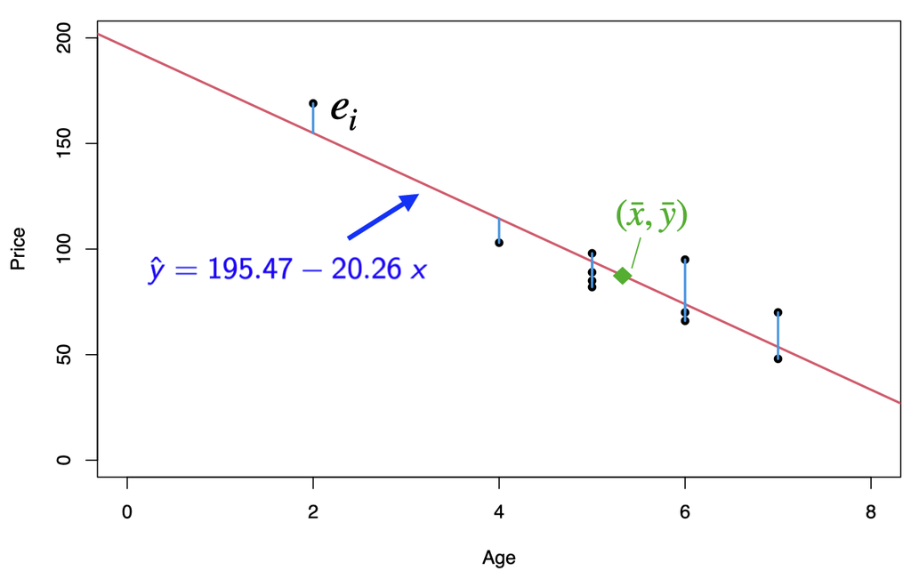

Back to our used cars example, we want to find the “best line” through the data points, which can be used to predict prices of used cars based on their age.

First we need to enter the data in R.

```r
Price<-c(85, 103,  70,  82,  89,  98,  66,  95, 169,  70,  48)
Age<- c(5, 4, 6, 5, 5, 5, 6, 6, 2, 7, 7)
carSales<-data.frame(Price,Age)
str(carSales)
```

```
## 'data.frame':    11 obs. of  2 variables:
##  $ Price: num  85 103 70 82 89 98 66 95 169 70 ...
##  $ Age  : num  5 4 6 5 5 5 6 6 2 7 ...
```

```r
cor(Age, Price, method = "pearson")
```

```
## [1] -0.9237821
```

Scatterplot: Age vs. Price

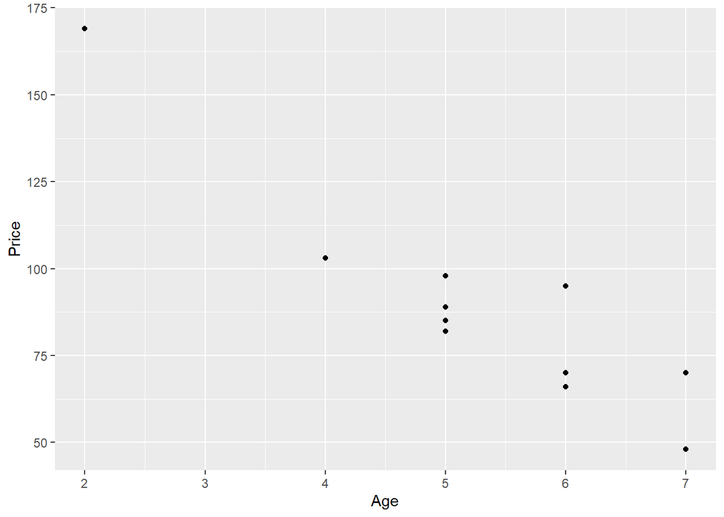

```r
library(ggplot2)
ggplot(carSales, aes(x=Age, y=Price)) + geom_point()
```

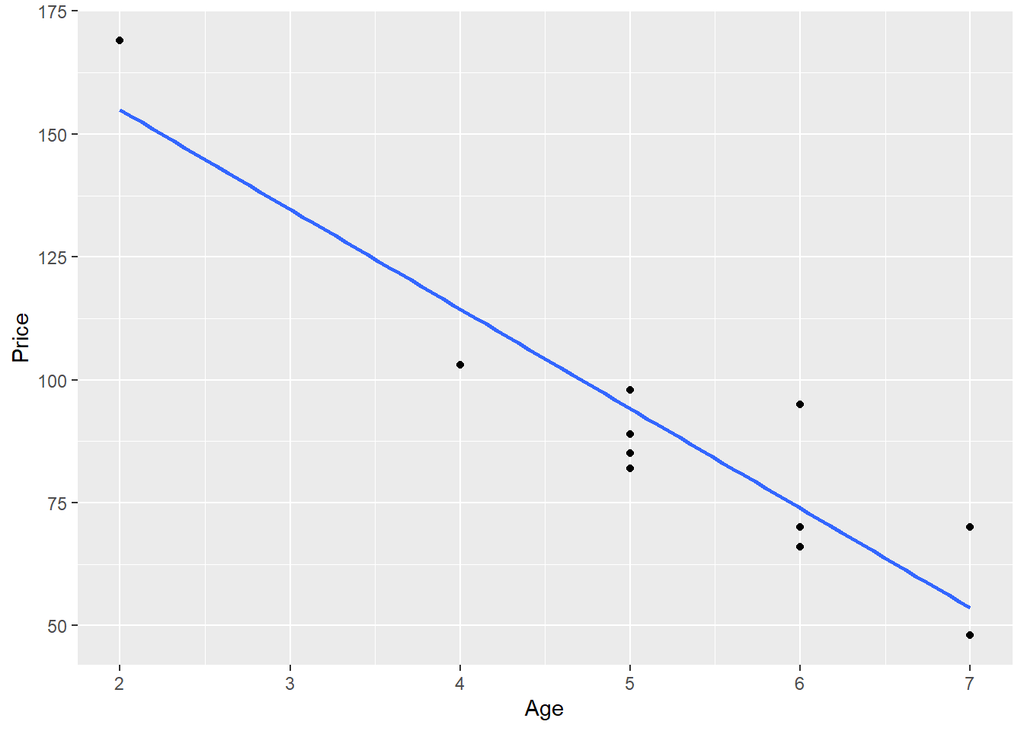

```r
# Remove the confidence interval
ggplot(carSales, aes(x=Age, y=Price)) +
  geom_point()+
  geom_smooth(method=lm, formula= y~x, se=FALSE)
```

## Prediction

```r
# simple linear regression
reg<-lm(Price~Age)
print(reg)
```

```
##
## Call:
## lm(formula = Price ~ Age)
##
## Coefficients:
## (Intercept)          Age
##      195.47       -20.26
```

To predict the price of a 4-year-old car ($x=4$):
$$\hat{y}=195.47-20.26(4)=114.43$$

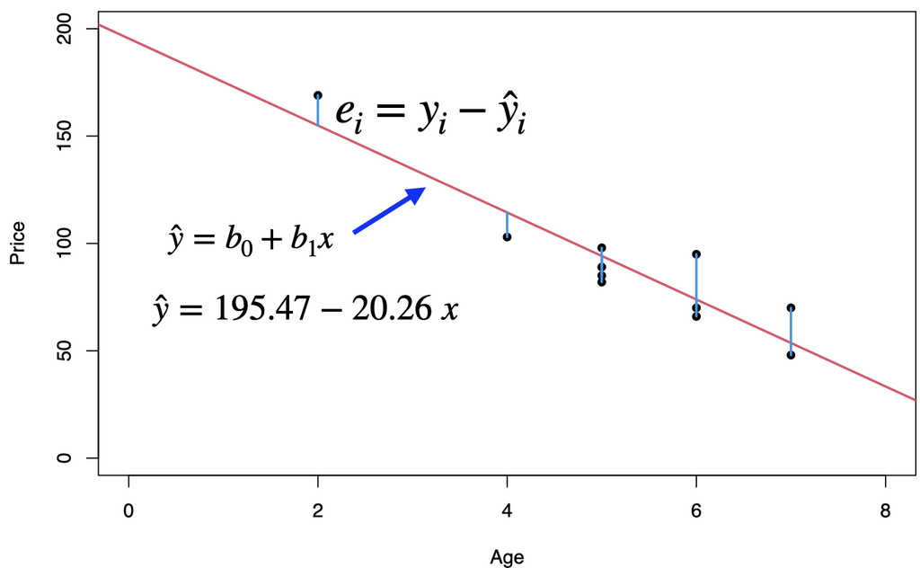